# context-dependent TF cooperation network construction

Cong

2024-09-03

# 1 import packages and functions

```r
suppressMessages(library(igraph))
suppressMessages(library(ggplot2))
suppressMessages(library(dplyr))
suppressMessages(library(RColorBrewer))
suppressMessages(library(huge))
suppressMessages(library(xlsx))

set.seed(42)
fl.sources <- list.files("../../scripts/utils/", full.names = T)
tmp <- sapply(fl.sources,source)
```

# 2 prepare TF-TF correlation input

Since each context (TRM or TexTerm) has several networks in different replicate samples, we first calculated the mean edge weight of TF-regulatee pair across samples. We kept regulatees with moderate variation across TFs (sd>1). Then we calculated the spearman correlation of TFs based on the edge weight profile.

- input: `edge_combined.csv` in each `network/` folder
- optional argument: pre-defined TF list, here, we only focus on TFs important in each context
- intermediate file: `mean_edge_weight.csv`: rows are regulatees (regulated downstream genes) and columns are TFs
- output: `TF_corr.csv`: rows and columns are TFs, symmetric matrix with diagonal as 1.

We’ll skip this part for demo purpose. The output file is provided.

```r
# sample <- 'TRM' # 'TRM' or 'TexTerm'
# tag <- '_subset_TFs_v2'
#
# L <- readLines(paste0(sample,'_samples.txt'))
# TFs <- readLines(paste0(sample,'_TFs_for_network_v3.txt'))
# TFs <- lapply(TFs, toupper)
#
#
# edge_weight <- do.call("rbind", lapply(L, function(x) read.table(paste0(x,'/edges_combined.csv'), sep = ",", header = T) %>% select(c(1,2,3)) %>% setNames(c("TF","regulatee","weight")))) %>% dplyr::filter(TF %in% TFs) %>%
#                group_by(TF, regulatee) %>% dplyr::summarize(weight = mean(weight, na.rm=TRUE)) %>%
#                reshape2::dcast(regulatee ~ TF, value.var = "weight", fill=0) %>%
#                tibble::column_to_rownames(var = "regulatee")
#
# df <- edge_weight %>% rowwise() %>% mutate(sd=sd(c_across(everything()))) %>% ungroup() %>%
#                 filter(sd>1) %>% select(!matches("MOUSE$|[0-9\\.]{6}$")) %>% select(-sd) %>%
#                 rename_with(firstup) %>% as.matrix %>% cor(method = "spearman") %>% as.data.frame
# write.csv(df,file = paste0("TF_corr_",sample,tag,".csv")) # write to file
```

```r
# load TF-TF correlation file
sample <- 'TexTerm' ### 'TRM' or 'TexTerm'
tag <- '_subset_TFs_v2'
df <- read.csv(paste0("TF_corr_",sample,tag,".csv"), row.names = 1)
knitr::kable(head(df[,1:6]), caption = 'TF-TF spearman correlation') |> kableExtra::kable_styling(latex_options = 'scale_down')
```

TF-TF spearman correlation

|  | Ahr | Arid3a | Arnt | Arntl | Atf1 | Atf2 |
| --- | --- | --- | --- | --- | --- | --- |
| Ahr | 1.0000000 | 0.0159095 | 0.1552732 | 0.0674772 | 0.0967936 | 0.0653700 |
| Arid3a | 0.0159095 | 1.0000000 | 0.1085567 | 0.0820837 | 0.1034220 | 0.1501552 |
| Arnt | 0.1552732 | 0.1085567 | 1.0000000 | 0.8563119 | 0.1860339 | 0.1763554 |
| Arntl | 0.0674772 | 0.0820837 | 0.8563119 | 1.0000000 | 0.1636281 | 0.1480576 |
| Atf1 | 0.0967936 | 0.1034220 | 0.1860339 | 0.1636281 | 1.0000000 | 0.5753676 |
| Atf2 | 0.0653700 | 0.1501552 | 0.1763554 | 0.1480576 | 0.5753676 | 1.0000000 |

```r
print(dim(df))
```

```
## [1] 170 170
```

# 3 copula pipeline to infer graph

We used R package `huge` to construct Gaussian graphical models (GGM) with copula modification. A little bit background to help with selction of hyper-parameters.

GGM assumes that the observations have a multivariate Gaussian distribution with mean $µ$, and covariance matrix $Σ$. The conditional independence can be implied by the inverse covariance (concentration) matrix $Ω = Σ^{−1}$. If $Ω_{jk} = 0$, then the i-th variable and j-th variables are conditional independent given all other variables.

This important property serves as the foundation for GGM to infer direct interactions from high-dimensional data. Unlike relevance networks or correlation networks, in which edges are determined based on marginal correlations, GGM provides a stronger criterion of dependency, and thus further reduces the false positive rate.

However, a great limitation of classic learning methods for GGM is the lack of sparsity in the resulting graph. A dense graph not only complicates downstream analysis but also raises the issue of overfitting the data. Thus it makes sense to impose an $ℓ$ penalty for the estimation of $Ω$, to increase its sparsity, and the sparse pattern of $Ω$ is essentially the same as the adjacency matrix of the underlying undirected graph.

Additionally, [Liu et al.](https://projecteuclid.org/journals/annals-of-statistics/volume-40/issue-4/High-dimensional-semiparametric-Gaussian-copula-graphical-models/10.1214/12-AOS1037.full) developed a data transformation method called Copula that can be used with the graphical Lasso algorithm to relax the normality assumption of GGM. The intuition of Copula is to infer the the relationship of the variables without being influenced by their individual distributions

For more details about package `huge`, check the [vignette](https://cran.r-project.org/web/packages/huge/vignettes/vignette.pdf). For instructions on selecting the hyper-parameters like `npn.func`, check the [manual](https://cran.r-project.org/web/packages/huge/huge.pdf)

```r
npn.func <- 'shrinkage'
df.npn <- huge.npn(df, npn.func = npn.func) # default
```

```
## Conducting the nonparanormal (npn) transformation via shrunkun ECDF....done.
```

```r
out.npn <- huge(df.npn, method = "glasso", nlambda = 30, lambda.min.ratio = 0.01) # fit glasso model to data
```

[output not shown]

```r
saveRDS(out.npn,paste0("result_copula_",sample,'_',npn.func,tag,".rds"))
```

The program automatically sets up a sequence of 30 regularization parameters and estimates the corresponding graph path.

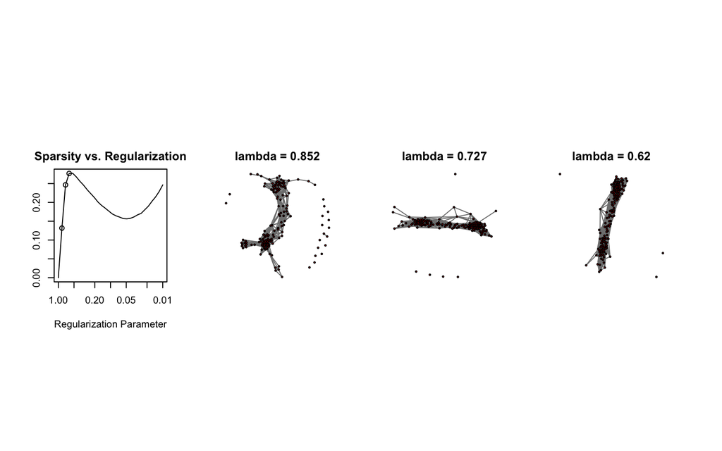

```r
# default visualization provided by huge package
plot(out.npn)
```

## 3.1 get precision matrix

From the above plot, we can see the local minimum of sparsity is 0.15. We can infer the precision matrix when sparsity=0.15

```r
sparsity <- 0.15
idx = which(out.npn$sparsity>=sparsity & out.npn$sparsity<=sparsity+0.01)[1]
print(paste0("lambda: ", out.npn$lambda[idx]))
```

```
## [1] "lambda: 0.0572582995483069"
```

```r
print(paste0("sparsity: ", out.npn$sparsity[idx]))
```

```
## [1] "sparsity: 0.157117995127045"
```

```r
m = out.npn$icov[[idx]]
rownames(m) <- rownames(df)
colnames(m) <- colnames(df)
knitr::kable(head(m[,1:6]), caption = 'sparse TF-TF correlation matrix') |> kableExtra::kable_styling(latex_options = 'scale_down')
```

sparse TF-TF correlation matrix

|  | Ahr | Arid3a | Arnt | Arntl | Atf1 | Atf2 |
| --- | --- | --- | --- | --- | --- | --- |
| Ahr | 3.1226310 | 0.0143988 | -0.0456422 | 0.0000000 | -0.1233884 | 0.0000000 |
| Arid3a | 0.0142164 | 4.9156918 | 0.0000000 | 0.0000000 | 0.0000000 | 0.0000000 |
| Arnt | -0.0457246 | 0.0000000 | 7.0673992 | -0.9341928 | 0.0000000 | 0.0000000 |
| Arntl | 0.0000000 | 0.0000000 | -0.9345756 | 7.2953688 | 0.0000000 | 0.0000000 |
| Atf1 | -0.1234237 | 0.0000000 | 0.0000000 | 0.0000000 | 5.7669647 | -0.0311552 |
| Atf2 | 0.0000000 | 0.0000000 | 0.0000000 | 0.0000000 | -0.0309058 | 5.5925174 |

```r
## write to file
write.csv(m, paste0("precision_copula_",sample,"_",npn.func,"_sparsity_",sparsity,tag,".csv"))
```

# 4 create igraph plot

## 4.1 create dataframe for igraph

```r
df <- data.frame(row=rownames(m)[row(m)[upper.tri(m)]],
                 col=colnames(m)[col(m)[upper.tri(m)]],
                 corr=m[upper.tri(m)])
### remove zero entries
df <- df[df$corr!=0,]
knitr::kable(head(df), caption = 'long form of TF correlation') |> kableExtra::kable_styling(latex_options = 'scale_down')
```

long form of TF correlation

|  | row | col | corr |
| --- | --- | --- | --- |
| 1 | Ahr | Arid3a | 0.0143988 |
| 2 | Ahr | Arnt | -0.0456422 |
| 6 | Arnt | Arntl | -0.9341928 |
| 7 | Ahr | Atf1 | -0.1233884 |
| 15 | Atf1 | Atf2 | -0.0311552 |
| 20 | Atf1 | Atf7 | -0.5549663 |

```r
print(dim(df))
```

```
## [1] 2257    3
```

```r
print(paste('percent of correlation score >','0',':',sum(df$corr > 0) *100 / nrow(df),"%"))
```

```
## [1] "percent of correlation score > 0 : 13.4692069118299 %"
```

```r
print(paste('percent of correlation score <','0',':',sum(df$corr < 0) *100 / nrow(df),"%"))
```

```
## [1] "percent of correlation score < 0 : 86.5307930881701 %"
```

```r
df$corr = abs(df$corr)
write.csv(df, paste0("correlation_intensity_table_copula_",sample,"_",npn.func,"_sparsity_",sparsity,tag,".csv"))
```

## 4.2 import node meta

Node annotation came from the results of Fig. S3a.

- `TRM_Tex`: multi-tasker in both TRM and TexTerm
- `Tex_specific`/`TRM_specific`: single-tasker in TexTerm/TRM
- `Tex_important`/`TRM_important`: important in TexTerm/TRM
- `Housekeeping`: 54 universal TFs with small variation across cell types

```r
nodes <- read.xlsx('TRM_Tex_TF_list_20240121.xlsx', sheetName = sample) %>% tidyr::drop_na(TF) %>% dplyr::mutate(group=ifelse(is.na(Specificity), Important, Specificity)) %>% select(TF, group)
names(nodes) <- c('name','group')
knitr::kable(head(nodes), caption = 'node meta') |> kableExtra::kable_styling(latex_options = 'scale_down')
```

node meta

| name | group |
| --- | --- |
| Bhlhe40 | TRM_Tex |
| Nr4a2 | TRM_Tex |
| Snai3 | TRM_Tex |
| Xbp1 | TRM_Tex |
| Egr1 | TRM_Tex |
| Nfil3 | TRM_Tex |

```r
print(dim(nodes))
```

```
## [1] 170   2
```

## 4.3 graph generation

```r
g = graph_from_data_frame(df, directed=FALSE, vertices = nodes)
print(g, e=TRUE, v=TRUE)
```

```
## IGRAPH acb6276 UN-- 170 2257 --
## + attr: name (v/c), group (v/c), corr (e/n)
## + edges from acb6276 (vertex names):
##  [1] Ahr    --Arid3a  Ahr    --Arnt    Arnt   --Arntl   Ahr    --Atf1
##  [5] Atf2   --Atf1    Atf1   --Atf7    Atf2   --Atf7    Arid3a --Bbx
##  [9] Bhlhe40--Arnt    Bhlhe40--Arntl   Bhlhe41--Arid3a  Bhlhe41--Arnt
## [13] Bhlhe41--Arntl   Bhlhe40--Bhlhe41 Ahr    --Cbfb    Cbfb   --Atf1
## [17] Batf   --Cbfb    Cebpb  --Atf2    Ahr    --Creb1   Creb1  --Atf1
## [21] Creb1  --Atf2    Creb1  --Atf7    Bhlhe41--Creb1   Crem   --Ahr
## [25] Crem   --Atf1    Crem   --Atf2    Crem   --Atf7    Crem   --Bhlhe41
## [29] Crem   --Creb1   Ctcf   --Atf1    Ctcf   --Bbx     Cebpb  --Ctcf
## + ... omitted several edges
```

## 4.4 Leiden clustering

Leiden clustering generates communities. Adjust the `res` to get a reasonable number of groups and high modularity score. High `res` gives more groups. Through experimenting, res=0.9 suits the best.

```r
set.seed(42)
res <- 0.9
clustering = cluster_leiden(g, objective_function="modularity",resolution_parameter=res)
print(clustering)
```

```
## IGRAPH clustering leiden, groups: 5, mod: NA
## + groups:
##   $`1`
##    [1] "Bhlhe40" "Xbp1"    "Max"     "Setbp1"  "Mxd1"    "Tigd2"   "Heyl"
##    [8] "Bhlhe41" "Tfeb"    "Usf1"    "Arnt"    "Mlx"     "Srebf1"  "Arntl"
##   [15] "Tfe3"
##
##   $`2`
##    [1] "Nr4a2"   "Nfil3"   "Gfi1"    "Crem"    "Tef"     "Zbtb3"   "Homez"
##    [8] "Thrb"    "Ddit3"   "Jun"     "Irf4"    "Meox2"   "Fos"     "Isl2"
##   [15] "Prdm1"   "Nfe2l1"  "Dmrt2"   "Eomes"   "Zbtb20"  "Irf8"    "Arid3a"
##   [22] "Foxj2"   "Batf"    "Nfatc1"  "Jund"    "Cebpb"   "Vax2"    "Foxd2"
##   + ... omitted several groups/vertices
```

```r
print(sizes(clustering))
```

```
## Community sizes
##  1  2  3  4  5
## 15 66 24 45 20
```

```r
print(paste0('modularity:',modularity(g, membership(clustering))))
```

```
## [1] "modularity:0.372509275038383"
```

```r
saveRDS(clustering,paste0('clustering_copula_',sample,'_',npn.func,'_res',res,'_s',sparsity,tag,'.rds'))
```

```r
## write clustering result
clust <- data.frame(name = names(membership(clustering)),cluster = as.numeric(membership(clustering))) %>%
        dplyr::inner_join(nodes, by = "name") %>%
        dplyr::arrange(group, cluster)
knitr::kable(head(clust), caption = 'community clustering') |> kableExtra::kable_styling(latex_options = 'scale_down')
```

community clustering

| name | cluster | group |
| --- | --- | --- |
| Creb1 | 2 | Housekeeping |
| Stat6 | 2 | Housekeeping |
| Irf3 | 2 | Housekeeping |
| Stat4 | 2 | Housekeeping |
| Gata3 | 2 | Housekeeping |
| Irf1 | 2 | Housekeeping |

```r
write.csv(clust,paste0('clustering_membership_copula_',sample,'_',npn.func,'_res',res,'_s',sparsity,tag,'.csv'), row.names=F)
```

## 4.5 visualization of graph

We need to set some parameters before plot:

- labeled nodes: perturb-seq targets and top degree nodes in each community
- node size: node degree
- color: community grouping
- color shade: common TFs in both contexts have darker shades
- edge width: correlation strength. Only top 10% edges are shown

```r
# load genes which we want to highlight in the plot
label_targets <- readLines(paste0(sample,'_gene_annotation.txt'))
common_targets <- readLines('common_genes_annotated.txt')

## generate top degree nodes for each community
clust <- data.frame(name = names(membership(clustering)),
                cluster = as.numeric(membership(clustering)),
                degree=degree(g)) %>%
dplyr::inner_join(nodes, by = "name") %>%
dplyr::group_by(cluster) %>% slice_max(order_by=degree, n = 5) %>% pull(name) %>%
writeLines(paste0('top_degree_nodes_per_community_',sample,'_',npn.func,'_res',res,"_s",sparsity,"_",sample,tag,'.txt'))

# combine top degree nodes to labeled list as well
tmp <- readLines(paste0('top_degree_nodes_per_community_',sample,'_',npn.func,'_res',res,"_s",sparsity,"_",sample,tag,'.txt'))
label_targets <- union(label_targets, tmp)

## add cluster info
V(g)$cluster <- clustering$membership # add community info to graph
V(g)$group <- ifelse(V(g)$name %in% label_targets,sample,"other")
V(g)$group2 <- ifelse(V(g)$name %in% common_targets,"common","specific")

# generate colors based on cluster
colors <- RColorBrewer::brewer.pal(length(clustering),"Set2")

V(g)$color <- colors[V(g)$cluster]
V(g)$color <- ifelse(V(g)$group2=='common',V(g)$color,paste0(V(g)$color,'7f')) # if common TFs, use darker shade

V(g)$frame.color <- "NA"

V(g)$label <- ifelse(V(g)$group == "other",NA,V(g)$name)
V(g)$label.color <- 'black'
V(g)$size <- 0.3*degree(g)
V(g)$label.cex <- 0.75

# set distance of label
V(g)$label.dist <- 0.4

# set edge color
E(g)$color <- "gray80"
# E(g)$size <- 0.1
E(g)$width <- 1.5*E(g)$corr
cut_off <- 0.9
E(g)$lty <- ifelse(E(g)$corr>=unname(quantile(E(g)$corr, cut_off)), 1, 0) # only show top edges

# set the within-module edges to some large weight, and the between module edges to some small weight
# and then choose 'layout_with_fr' to make the grouped layout
edge.weights <- function(community, network, weight.within = 10, weight.between = 1) {
    bridges <- crossing(communities = community, graph = network)
    weights <- ifelse(test = bridges, yes = weight.between, no = weight.within)
    return(weights)
}
E(g)$weight <- edge.weights(clustering, g)
```

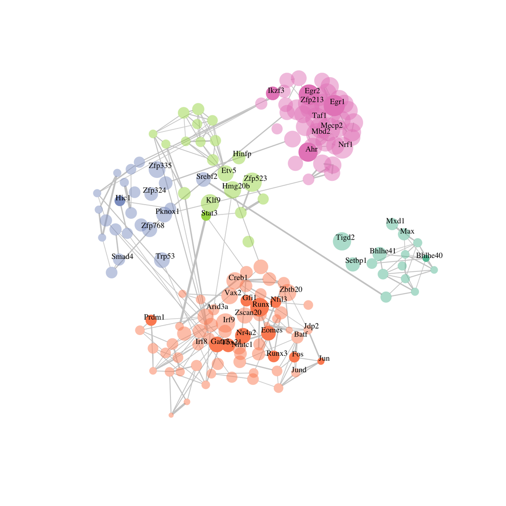

```r
plot(g, layout=layout_with_fr)
```

```r
## write graph to object
saveRDS(g, paste0("graph_",npn.func,'_res',res,"_s",sparsity,"_",sample,"_",tag,".rds"))
```